# 빅데이터시각화_7장

### 지도 다루기

#### 1. 지도 불러오기

##### get_map{ggmap}

get_map{ggmap} 함수는 Google Maps, OpenStreetMap, Stamen Maps 또는 Naver Map servers에서 지도를 가져온다.

```
get_map(location=c(lon=-95.3632715, lat=29.7632836),
        zoom="auto", scale="auto",
        maptype=c("terrain", "satellite", "roadmap","hybrid",
                  "toner", "watercolor", ...),
        source=c("google","osm", "stemen", "cloudmade"),
        force=ifelse(source == "google", TRUE, TRUE),
        messaging=FALSE, urlonly=FALSE, fileneame="ggmapTemp",
        crop=TRUE, color=c("color", "bw"), language="en-EN", api_key)
```

위 함수에 대한 주요 옵션은 다음과 같다.

```
- location : 주소, 경도/위도 또는 왼/아래/오른/위쪽 경계 박스
- zoom : 맵의 줌. 3(대륙) ~ 21(빌딩). default는 10(시, city)
- scale : get_googlemap 또는 get_openstreetmap의 척도 인자
- maptype : 문자열로 맵의 형태 지정
            "terrain", "terrain-background", "satellite", "roadmap","hybrid"(google maps)
            watercolor", and "toner"(stamen maps), or 양의 정수(cloudmade maps)
- source : 지도의 소스
            Google Maps("google"), OpenStreetMap("osm"), Stamen Maps("stamen")
            or CloudMade maps("cloudmade")
- filename : 다운로드를 위한 위치 지정
- color : color("색(영어로)") 또는 black-and-white("bw")
- language : google maps를 위한 언어
```

##### (a) 맵의 형태에 따른 지도 유형

```r
## maptype= 옵션에 따른 지도 유형
#library(ggmap)
# roadmap, satellite, terrain, watercolor, hybrid, toner
# map.1 <- get_map(location="Seoul", zoom=14, maptype="roadmap", source="google")
# g <- ggmap(map.1)
# print(g)
```

##### (b) 줌의 크기에 따른 지도의 크기

```r
## zoom= 옵션에 따른 지도 크기
# library(ggmap)
# map <- get_map(location="Seoul, South Korea", zoom=10, maptype="satellite")
# p <- ggmap(map)
# p <- p + labs(title="Seoul, South Korea -satellite")
# print(p)
# zoom=10; 서울 지도(location="Seoul"), maptype="satellite","roadmap"
# zoom=3, 5; 남한(location="South Korea") 지도
# zoom=7, 9; 서울(location="Seoul") 지도
# zoom=19,19; 서울시청(location="Seoul City Hall", maptype="roadmap"),
#             서울타워(location="Seoul Tower", maptype="satellite")
```

##### (c) 랜드마크 설정

지도상에 특정 지점을 표히사는 방법은 다음과 같다.  
원하는 지점의 위치 정보(위도, 경도)가 필요하다.

```r
# library(ggmap)
# map.1 <- get_map(location="Seoul", zoom=14, maptype="roadmap", source="google")
# g <- ggmap(map.1)
# print(g)
# landmarks <- c("Seoul Tower", "City Hall, Seoul")
# lbls <- cbind(geocode(landmarks), text=landmarks)
# g <- ggmap(map.1)
# g <- g + geom_point(data=lbls, aes(x=lon, y=lat), size=5, colour="orange")
# g <- g + geom_point(data=lbls, aes(x=lon, y=lat), size=5, colour="red")
# g <- g + geom_text(data=lbls, aes(x=lon, y=lat, label=text),
#                      size=5, colour="blue", hjust=0, vjust=0)
# print(g)
```

#### 2. 지도 활용 예제

##### 예제 1

USArrests 자료에서 주(states)별 폭행별 살인 비율(murder/assault)을 지도상에 시각화한다.

```r
library(ggplot2)
arrests <- USArrests  # {ggplot2}에 내장되어 있는 미국의 범죄 데이터
names(arrests) <- tolower(names(arrests))
arrests$region <- tolower(rownames(USArrests))
head(arrests)
```

```
##            murder assault urbanpop rape     region
## Alabama      13.2     236       58 21.2    alabama
## Alaska       10.0     263       48 44.5     alaska
## Arizona       8.1     294       80 31.0    arizona
## Arkansas      8.8     190       50 19.5   arkansas
## California    9.0     276       91 40.6 california
## Colorado      7.9     204       78 38.7   colorado
```

```r
library(ggmap)
```

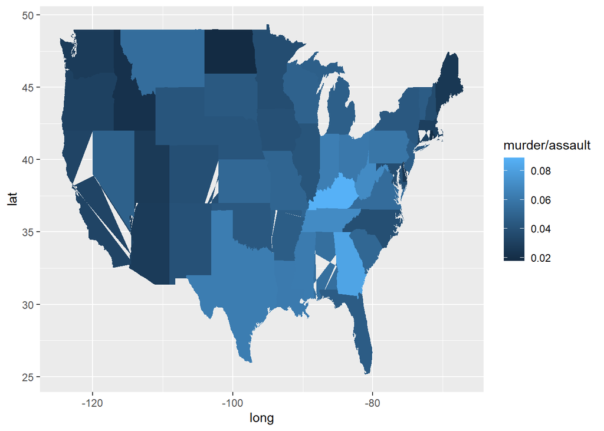

```r
states <- map_data("state")  # 미국의 주별 지도 데이터 불러오기
## 범죄데이터와 주별 지도 데이터 합치기
ds <- merge(states, arrests, sort=FALSE, by="region")
## 그림으로 나타내기 (폭행별 살인 비율)
g <- ggplot(ds, aes(long, lat, group=group, fill=murder/assault))
## 영역을 채움
g <- g + geom_polygon()
print(g)
```

##### 예제 2 서울시의 공공 와이파이 위치정보 시각화

```r
# library(ggmap)
# wifi = read.csv("wifi.csv")
# attach(wifi)
# cent <- c(mean(longitude), mean(latitude))  # 위도, 경도의 평균

## 서울시 지도에 와이파이 기지국 데이터 표시하기
# wifi.map <- ggmap(get_googlemap(center=cent, #center=c("seoul") 도 가능
#                                 zoom=11, maptype="roadmap"))
#         + geom_point(data=wifi, aes(x=longitude, y=latitude, colour=supplier, size=4))
# print(wifi.map)
# wifi.map + facet_wrap(~supplier)  # 통신사별로 나누어서 표현
```

##### 예제 3 한국과 일본 간 항공편 정보 시각화

```r
# str(airport.krjp)
# str(lines)
```

```r
# map <- ggmap(get_googlemap(center=c(lon=134, lat=36),
#                            zoom=5, maptype='roadmap',
#                            color='bw', scale=2),
#              extent='device')

# map + geom_point(data=airpot.krjp, aes(x=longitude, y=latitude, size=Freq),
#                  colour='gray10', alpha=0.3)
#   + geom_line(data=lines, aes(x=longitude, y=latitude, group=group),
#              size=0.2, alpha=.1, color='#816960')
#   + scale_size(range=c(0,15))
#   + theme(legend.position="none")
```